# UnivariateAssignment

Julie Raiguel

January 30, 2018

## Subset Data

This code reads in the dataset and allows me to see what that data looks like.

```r
trees = read.csv('../data/treedata_subset.csv')

head(trees)
```

```
##         plotID  spcode       species cover elev       tci streamdist
## 1 ATBN-01-0403 ABIEFRA Abies fraseri     1 1660  5.701460      490.9
## 2 ATBN-01-0532 ABIEFRA Abies fraseri     8 1712  3.823586      454.0
## 3 ATBN-01-0533 ABIEFRA Abies fraseri     3 1722  3.893762      453.4
## 4 ATBN-01-0536 ABIEFRA Abies fraseri     3 1754  3.145527      492.5
## 5 FRID-01-0003 ABIEFRA Abies fraseri     5 1570 11.850000        0.0
## 6 PITT-01-0045 ABIEFRA Abies fraseri     2 1504  4.373741      237.1
##   disturb     beers
## 1 CORPLOG 0.2244286
## 2  VIRGIN 0.8340878
## 3  LT-SEL 1.3332586
## 4  SETTLE 1.4712484
## 5  LT-SEL 0.4961189
## 6  VIRGIN 1.6558421
```

In this code, I make two subsets of trees. One is all of the rows for Acer rubrum. The other is for all of the rows of Abies fraseri. In each, I use summary to make sure it subsetted correctly.

```r
acer_sub = subset(trees, subset = spcode == 'ACERRUB')
head(acer_sub)
```

```
##          plotID  spcode     species cover   elev      tci streamdist
## 48 ATBN-01-0303 ACERRUB Acer rubrum     6  896.1 4.705636     197.00
## 49 ATBN-01-0304 ACERRUB Acer rubrum     7  947.3 4.447437     125.30
## 50 ATBN-01-0305 ACERRUB Acer rubrum     5 1027.0 6.149170     174.60
## 51 ATBN-01-0306 ACERRUB Acer rubrum     7  450.2 4.133772     202.50
## 52 ATBN-01-0307 ACERRUB Acer rubrum     5  477.0 5.587310     134.20
## 53 ATBN-01-0308 ACERRUB Acer rubrum     4  461.8 4.415634      31.62
##    disturb     beers
## 48 CORPLOG 1.9906803
## 49 CORPLOG 0.8167341
## 50 CORPLOG 0.5860782
## 51  LT-SEL 0.8601108
## 52  LT-SEL 0.1009244
## 53  LT-SEL 1.4324567
```

```r
summary(acer_sub)
```

```
##           plotID        spcode                     species
##  UFRL-01-0047:  4   ACERRUB:723   Acer rubrum          :723
##  UFRL-01-0048:  4   ABIEFRA:  0   Abies fraseri        :  0
##  UFRL-01-0090:  4   ACERNEG:  0   Acer negundo         :  0
##  UFRL-01-0091:  4   ACERNIG:  0   Acer nigrum          :  0
##  UFRL-01-0092:  4   AILAALT:  0   Ailanthus altissima  :  0
##  UFRL-01-0093:  4   BETUALL:  0   Betula alleghaniensis:  0
##  (Other)     :699   (Other):  0   (Other)              :  0
##      cover             elev             tci           streamdist
##  Min.   : 1.000   Min.   : 266.7   Min.   : 2.610   Min.   :  0.00
##  1st Qu.: 4.000   1st Qu.: 601.9   1st Qu.: 4.564   1st Qu.: 68.54
##  Median : 6.000   Median : 802.1   Median : 5.226   Median :194.20
##  Mean   : 5.133   Mean   : 857.6   Mean   : 5.837   Mean   :218.69
##  3rd Qu.: 6.000   3rd Qu.:1077.0   3rd Qu.: 6.408   3rd Qu.:328.00
##  Max.   :10.000   Max.   :1551.0   Max.   :25.000   Max.   :957.50
##
##     disturb        beers
##  CORPLOG:147   Min.   :0.000106
##  LT-SEL :343   1st Qu.:0.311609
##  SETTLE :123   Median :1.068436
##  VIRGIN :110   Mean   :1.024309
##                3rd Qu.:1.687648
##                Max.   :1.999999
##
```

```r
abies_sub= subset(trees, subset = spcode == 'ABIEFRA')
head(abies_sub)
```

```
##         plotID  spcode       species cover elev       tci streamdist
## 1 ATBN-01-0403 ABIEFRA Abies fraseri     1 1660  5.701460      490.9
## 2 ATBN-01-0532 ABIEFRA Abies fraseri     8 1712  3.823586      454.0
## 3 ATBN-01-0533 ABIEFRA Abies fraseri     3 1722  3.893762      453.4
## 4 ATBN-01-0536 ABIEFRA Abies fraseri     3 1754  3.145527      492.5
## 5 FRID-01-0003 ABIEFRA Abies fraseri     5 1570 11.850000        0.0
## 6 PITT-01-0045 ABIEFRA Abies fraseri     2 1504  4.373741      237.1
##   disturb     beers
## 1 CORPLOG 0.2244286
## 2  VIRGIN 0.8340878
## 3  LT-SEL 1.3332586
## 4  SETTLE 1.4712484
## 5  LT-SEL 0.4961189
## 6  VIRGIN 1.6558421
```

```r
summary(abies_sub)
```

```
##           plotID       spcode                    species       cover
##  UFRL-06-0133: 4   ABIEFRA:44   Abies fraseri        :44   Min.   :1.000
##  UFRL-06-0134: 4   ACERNEG: 0   Acer negundo         : 0   1st Qu.:4.000
##  UFRL-06-0135: 4   ACERNIG: 0   Acer nigrum          : 0   Median :6.000
##  UFRL-06-0136: 4   ACERRUB: 0   Acer rubrum          : 0   Mean   :6.023
##  UFRL-06-0137: 4   AILAALT: 0   Ailanthus altissima  : 0   3rd Qu.:8.000
##  UFRL-06-0139: 4   BETUALL: 0   Betula alleghaniensis: 0   Max.   :9.000
##  (Other)     :20   (Other): 0   (Other)              : 0
##       elev           tci           streamdist       disturb
##  Min.   :1504   Min.   : 3.146   Min.   :  0.0   CORPLOG: 1
##  1st Qu.:1760   1st Qu.: 4.370   1st Qu.:364.0   LT-SEL : 2
##  Median :1871   Median : 5.646   Median :460.1   SETTLE : 1
##  Mean   :1833   Mean   : 5.544   Mean   :486.7   VIRGIN :40
##  3rd Qu.:1932   3rd Qu.: 5.899   3rd Qu.:535.6
##  Max.   :1992   Max.   :11.850   Max.   :836.5
##
##      beers
##  Min.   :0.1199
##  1st Qu.:0.7868
##  Median :1.3891
##  Mean   :1.2582
##  3rd Qu.:1.8273
##  Max.   :1.9867
##
```

This code makes a plot of the response variable (cover) against one of the explanatory variables (elevation). There seems to be a positive correlation between the two.

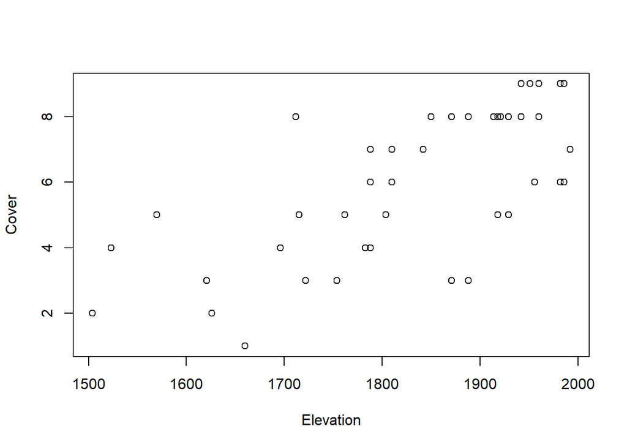

```r
plot(abies_sub$cover~ abies_sub$elev, xlab = 'Elevation', ylab = 'Cover')
```

## Making the *Abies* Model

This code is used to see check for interactions between variables. This chart was not used because it includes non-explanatory variables like species name.

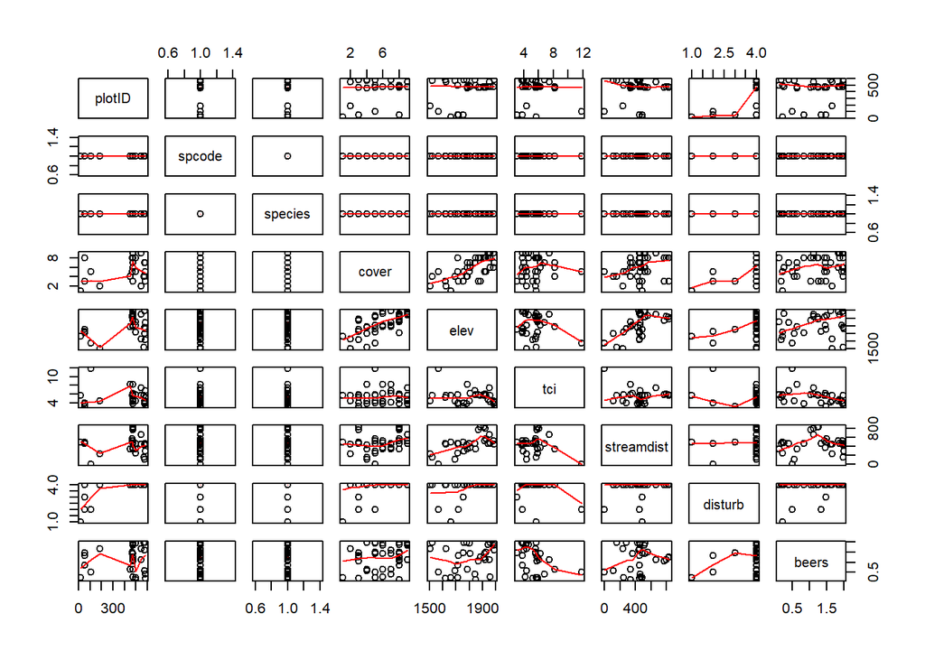

```r
pairs(abies_sub, panel=panel.smooth)
```

This code removes all variables except for the possible explanatory ones and the reponse variable. The plot is made again between these variables. It is easy to see a much better correlation between cover and elevation than cover and beers, so elevation will probably be more significant in the model. There appears to be little correlation between explanatory variables other than between elevation and tci, elevation and stream distance and tci and stream distance, so these relationships will be tested to see if they should be included in the model.

```r
names(abies_sub)
```

```
## [1] "plotID"     "spcode"     "species"    "cover"      "elev"
## [6] "tci"        "streamdist" "disturb"    "beers"
```

```r
abies_expvar = abies_sub[1:nrow(abies_sub), 4:9]
head(abies_expvar)
```

```
##   cover elev       tci streamdist disturb     beers
## 1     1 1660  5.701460      490.9 CORPLOG 0.2244286
## 2     8 1712  3.823586      454.0  VIRGIN 0.8340878
## 3     3 1722  3.893762      453.4  LT-SEL 1.3332586
## 4     3 1754  3.145527      492.5  SETTLE 1.4712484
## 5     5 1570 11.850000        0.0  LT-SEL 0.4961189
## 6     2 1504  4.373741      237.1  VIRGIN 1.6558421
```

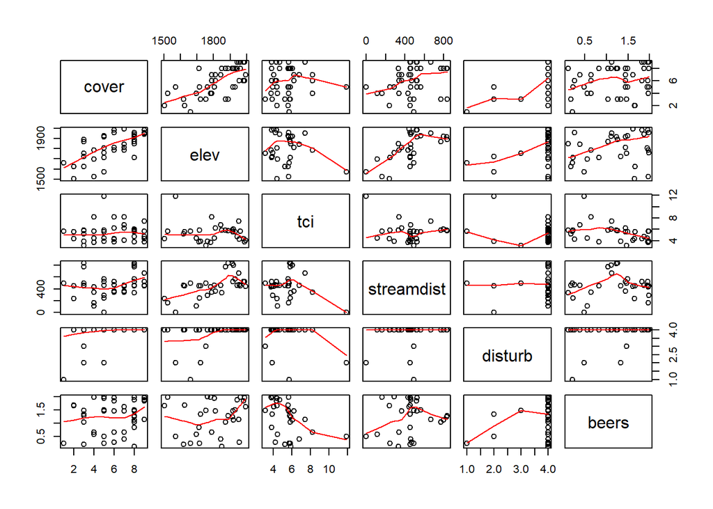

```r
pairs(abies_expvar, panel = panel.smooth)
```

### Making the maximal model with no interactions

The maximal OLS model includes all 5 possible explanatory variables (elev, tci, streamdist, disturb, and beers). The Residuals vs. Fitted plot is just okay since there is a bit of a pattern. 2, 14, and 15 are identified as outliers. The Normal Q-Q plot shows that the model fits okay since the many of the points are on the dashed line. The same outliers are identified. The Scale-Location plot shows slight heteroscedasticity to the right and identifies the same outliers. The Residuals vs. Leverage plot shows 2, 3, and 5 as outliers. The summary indicates R-squared is 0.5824 and the adjusted R-squared is 0.5011.

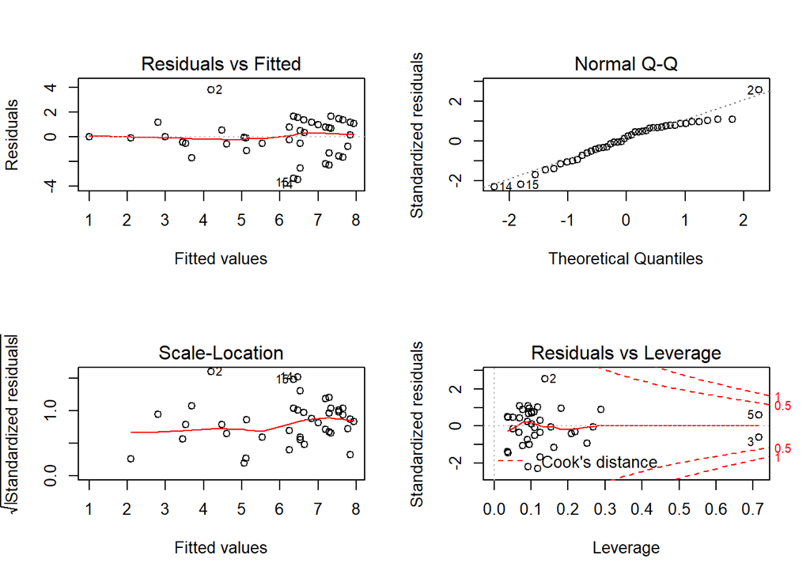

```r
abies_modmax = lm(abies_sub$cover ~ abies_sub$elev + abies_sub$tci + abies_sub$streamdist + abies_sub$disturb + abies_sub$beers)

par(mfrow=c(2,2))
plot(abies_modmax)
```

```r
summary(abies_modmax)
```

```
##
## Call:
## lm(formula = abies_sub$cover ~ abies_sub$elev + abies_sub$tci +
##     abies_sub$streamdist + abies_sub$disturb + abies_sub$beers)
##
## Residuals:
##     Min      1Q  Median      3Q     Max
## -3.4630 -0.6472  0.0788  1.0872  3.8017
##
## Coefficients:
##                           Estimate Std. Error t value Pr(>|t|)
## (Intercept)             -20.561173   4.271449  -4.814 2.65e-05 ***
## abies_sub$elev            0.012370   0.002523   4.903 2.02e-05 ***
## abies_sub$tci             0.287641   0.193467   1.487   0.1458
## abies_sub$streamdist     -0.001266   0.001585  -0.799   0.4296
## abies_sub$disturbLT-SEL   2.188367   2.097905   1.043   0.3038
## abies_sub$disturbSETTLE   1.527604   2.341471   0.652   0.5183
## abies_sub$disturbVIRGIN   3.025596   1.735921   1.743   0.0899 .
## abies_sub$beers           0.037551   0.500269   0.075   0.9406
## ---
## Signif. codes:  0 '***' 0.001 '**' 0.01 '*' 0.05 '.' 0.1 ' ' 1
##
## Residual standard error: 1.601 on 36 degrees of freedom
## Multiple R-squared:  0.5824, Adjusted R-squared:  0.5011
## F-statistic: 7.171 on 7 and 36 DF,  p-value: 2.215e-05
```

### Subtracting from the maximal model

```r
abies_modmax_wobeers = update(abies_modmax, ~. -abies_sub$beers)

summary(abies_maxmod_wobeers)
```

[output not shown]

The next least significant variable is one of the disturb categories. When it is removed the adjusted R-squared goes down, so disturb is left in. The disturb category with the very low p-value must be significant enough that this variable helps explain cover.

```r
abies_wobeers_wodisturb = update(abies_modmax_wobeers, ~. -abies_sub$disturb)

summary(abies_wobeers_wodisturb)
```

```
##
## Call:
## lm(formula = abies_sub$cover ~ abies_sub$elev + abies_sub$tci +
##     abies_sub$streamdist)
##
## Residuals:
##     Min      1Q  Median      3Q     Max
## -3.2734 -1.0727  0.1282  1.1105  4.1294
##
## Coefficients:
##                        Estimate Std. Error t value Pr(>|t|)
## (Intercept)          -20.592971   4.113294  -5.006 1.16e-05 ***
## abies_sub$elev         0.014080   0.002330   6.044 4.10e-07 ***
## abies_sub$tci          0.293155   0.161110   1.820   0.0763 .
## abies_sub$streamdist  -0.001677   0.001552  -1.081   0.2863
## ---
## Signif. codes:  0 '***' 0.001 '**' 0.01 '*' 0.05 '.' 0.1 ' ' 1
##
## Residual standard error: 1.605 on 40 degrees of freedom
## Multiple R-squared:  0.534,  Adjusted R-squared:  0.499
## F-statistic: 15.28 on 3 and 40 DF,  p-value: 8.951e-07
```

Next, streamdist is removed because of its high p-value. The adjusted R-squared increased to 0.5188, so this model fits the data better. Stream and beers remain out of the simplified model.

```r
abies_wobeers_wostream = update(abies_modmax_wobeers, ~. -abies_sub$streamdist)

summary(abies_wobeers_wostream)
```

```
##
## Call:
## lm(formula = abies_sub$cover ~ abies_sub$elev + abies_sub$tci +
##     abies_sub$disturb)
##
## Residuals:
##     Min      1Q  Median      3Q     Max
## -3.8466 -0.6996  0.2255  0.8636  3.6846
##
## Coefficients:
##                          Estimate Std. Error t value Pr(>|t|)
## (Intercept)             -19.33664    3.90928  -4.946 1.57e-05 ***
## abies_sub$elev            0.01128    0.00200   5.641 1.77e-06 ***
## abies_sub$tci             0.28248    0.17025   1.659   0.1053
## abies_sub$disturbLT-SEL   2.54484    1.96059   1.298   0.2021
## abies_sub$disturbSETTLE   1.66160    2.26912   0.732   0.4685
## abies_sub$disturbVIRGIN   3.25929    1.63542   1.993   0.0535 .
## ---
## Signif. codes:  0 '***' 0.001 '**' 0.01 '*' 0.05 '.' 0.1 ' ' 1
##
## Residual standard error: 1.573 on 38 degrees of freedom
## Multiple R-squared:  0.5748, Adjusted R-squared:  0.5188
## F-statistic: 10.27 on 5 and 38 DF,  p-value: 2.774e-06
```

Next, tci and elev are each removed. The R-squared goes down each time, so these variables are returned in the simplified model.

```r
abies_wobwos_wotci = update(abies_wobeers_wostream, ~. -abies_sub$tci)
summary(abies_wobwos_wotci)
```

```
##
## Call:
## lm(formula = abies_sub$cover ~ abies_sub$elev + abies_sub$disturb)
##
## Residuals:
##     Min      1Q  Median      3Q     Max
## -3.7526 -1.0328  0.3993  1.1899  3.1561
##
## Coefficients:
##                           Estimate Std. Error t value Pr(>|t|)
## (Intercept)             -17.002142   3.728354  -4.560 4.96e-05 ***
## abies_sub$elev            0.010845   0.002027   5.351 4.11e-06 ***
## abies_sub$disturbLT-SEL   3.151825   1.968962   1.601   0.1175
## abies_sub$disturbSETTLE   0.980602   2.281293   0.430   0.6697
## abies_sub$disturbVIRGIN   3.279968   1.671719   1.962   0.0569 .
## ---
## Signif. codes:  0 '***' 0.001 '**' 0.01 '*' 0.05 '.' 0.1 ' ' 1
##
## Residual standard error: 1.607 on 39 degrees of freedom
## Multiple R-squared:  0.544,  Adjusted R-squared:  0.4972
## F-statistic: 11.63 on 4 and 39 DF,  p-value: 2.603e-06
```

```r
abies_wobwos_woelev = update(abies_wobeers_wostream, ~. -abies_sub$elev)
summary(abies_wobwos_woelev)
```

```
##
## Call:
## lm(formula = abies_sub$cover ~ abies_sub$tci + abies_sub$disturb)
##
## Residuals:
##     Min      1Q  Median      3Q     Max
## -4.3465 -1.3457  0.1255  1.6231  2.9358
##
## Coefficients:
##                         Estimate Std. Error t value Pr(>|t|)
## (Intercept)               0.1092     2.4667   0.044   0.9649
## abies_sub$tci             0.1562     0.2258   0.692   0.4931
## abies_sub$disturbLT-SEL   2.6609     2.6231   1.014   0.3166
## abies_sub$disturbSETTLE   2.3993     3.0311   0.792   0.4334
## abies_sub$disturbVIRGIN   5.3591     2.1308   2.515   0.0161 *
## ---
## Signif. codes:  0 '***' 0.001 '**' 0.01 '*' 0.05 '.' 0.1 ' ' 1
##
## Residual standard error: 2.104 on 39 degrees of freedom
## Multiple R-squared:  0.2187, Adjusted R-squared:  0.1385
## F-statistic: 2.729 on 4 and 39 DF,  p-value: 0.04281
```

The simplified model is the one with beers and streamdist variables removed since these are not significant. Elev is most significant and then the virgin category of disturb followed by the tci. The plots have not changed much from the maximal model because beers and streamdist were not affecting the model very much.

```r
abies_simpmod = abies_wobeers_wostream

summary(abies_simpmod)
```

```
##
## Call:
## lm(formula = abies_sub$cover ~ abies_sub$elev + abies_sub$tci +
##     abies_sub$disturb)
##
## Residuals:
##     Min      1Q  Median      3Q     Max
## -3.8466 -0.6996  0.2255  0.8636  3.6846
##
## Coefficients:
##                          Estimate Std. Error t value Pr(>|t|)
## (Intercept)             -19.33664    3.90928  -4.946 1.57e-05 ***
## abies_sub$elev            0.01128    0.00200   5.641 1.77e-06 ***
## abies_sub$tci             0.28248    0.17025   1.659   0.1053
## abies_sub$disturbLT-SEL   2.54484    1.96059   1.298   0.2021
## abies_sub$disturbSETTLE   1.66160    2.26912   0.732   0.4685
## abies_sub$disturbVIRGIN   3.25929    1.63542   1.993   0.0535 .
## ---
## Signif. codes:  0 '***' 0.001 '**' 0.01 '*' 0.05 '.' 0.1 ' ' 1
##
## Residual standard error: 1.573 on 38 degrees of freedom
## Multiple R-squared:  0.5748, Adjusted R-squared:  0.5188
## F-statistic: 10.27 on 5 and 38 DF,  p-value: 2.774e-06
```

```r
par(mfrow= c(2,2))
plot(abies_simpmod)
```

[output not shown]

### Adding interactions

Interactions should only be added if they are significant to the model because they make it more complex. The adjusted R-squared values are compared when the correlations identified at the beginning of this analysis are added (elev, tci, and streamdist).

```r
summary(update(abies_simpmod, ~. + elev*tci, data = abies_sub))
```

```
##
## Call:
## lm(formula = abies_sub$cover ~ abies_sub$elev + abies_sub$tci +
##     abies_sub$disturb + elev + tci + elev:tci, data = abies_sub)
##
## Residuals:
##     Min      1Q  Median      3Q     Max
## -3.8360 -0.6463  0.2292  0.8729  3.6874
##
## Coefficients: (2 not defined because of singularities)
##                           Estimate Std. Error t value Pr(>|t|)
## (Intercept)             -2.087e+01  1.188e+01  -1.757   0.0872 .
## abies_sub$elev           1.216e-02  6.693e-03   1.816   0.0774 .
## abies_sub$tci            5.808e-01  2.180e+00   0.266   0.7914
## abies_sub$disturbLT-SEL  2.455e+00  2.092e+00   1.173   0.2482
## abies_sub$disturbSETTLE  1.667e+00  2.299e+00   0.725   0.4729
## abies_sub$disturbVIRGIN  3.272e+00  1.660e+00   1.972   0.0562 .
## elev                            NA         NA      NA       NA
## tci                             NA         NA      NA       NA
## elev:tci                -1.708e-04  1.245e-03  -0.137   0.8916
## ---
## Signif. codes:  0 '***' 0.001 '**' 0.01 '*' 0.05 '.' 0.1 ' ' 1
##
## Residual standard error: 1.593 on 37 degrees of freedom
## Multiple R-squared:  0.575,  Adjusted R-squared:  0.5061
## F-statistic: 8.342 on 6 and 37 DF,  p-value: 9.519e-06
```

The adjusted R-squared value went down and the p-value is high, so this interaction is removed, and the next is added. When the interaction between elev and streamdist was added, the same occurred.

```r
summary(update(abies_simpmod, ~. + elev*streamdist, data = abies_sub))
```

```
##
## Call:
## lm(formula = abies_sub$cover ~ abies_sub$elev + abies_sub$tci +
##     abies_sub$disturb + elev + streamdist + elev:streamdist,
##     data = abies_sub)
##
## Residuals:
##     Min      1Q  Median      3Q     Max
## -3.5426 -0.8616  0.0421  0.9471  3.9962
##
## Coefficients: (1 not defined because of singularities)
##                           Estimate Std. Error t value Pr(>|t|)
## (Intercept)             -1.169e+01  1.012e+01  -1.155    0.256
## abies_sub$elev           7.908e-03  5.263e-03   1.503    0.142
## abies_sub$tci            2.252e-01  1.807e-01   1.246    0.221
## abies_sub$disturbLT-SEL  1.525e+00  2.137e+00   0.714    0.480
## abies_sub$disturbSETTLE  1.270e+00  2.304e+00   0.551    0.585
## abies_sub$disturbVIRGIN  2.597e+00  1.730e+00   1.501    0.142
## elev                            NA         NA      NA       NA
## streamdist              -2.386e-02  2.346e-02  -1.017    0.316
## elev:streamdist          1.227e-05  1.271e-05   0.965    0.341
##
## Residual standard error: 1.581 on 36 degrees of freedom
## Multiple R-squared:  0.5928, Adjusted R-squared:  0.5137
## F-statistic: 7.488 on 7 and 36 DF,  p-value: 1.461e-05
```

Again…

```r
summary(update(abies_simpmod, ~. + tci*streamdist, data = abies_sub))
```

```
##
## Call:
## lm(formula = abies_sub$cover ~ abies_sub$elev + abies_sub$tci +
##     abies_sub$disturb + tci + streamdist + tci:streamdist, data = abies_sub)
##
## Residuals:
##     Min      1Q  Median      3Q     Max
## -3.4823 -0.6251  0.0997  1.1619  3.7234
##
## Coefficients: (1 not defined because of singularities)
##                           Estimate Std. Error t value Pr(>|t|)
## (Intercept)             -2.074e+01  4.383e+00  -4.732 3.40e-05 ***
## abies_sub$elev           1.230e-02  2.556e-03   4.814 2.65e-05 ***
## abies_sub$tci            3.326e-01  3.591e-01   0.926   0.3605
## abies_sub$disturbLT-SEL  2.070e+00  2.248e+00   0.921   0.3631
## abies_sub$disturbSETTLE  1.481e+00  2.357e+00   0.628   0.5337
## abies_sub$disturbVIRGIN  3.073e+00  1.686e+00   1.822   0.0767 .
## tci                             NA         NA      NA       NA
## streamdist              -2.016e-04  6.752e-03  -0.030   0.9763
## tci:streamdist          -1.705e-04  1.043e-03  -0.163   0.8711
## ---
## Signif. codes:  0 '***' 0.001 '**' 0.01 '*' 0.05 '.' 0.1 ' ' 1
##
## Residual standard error: 1.601 on 36 degrees of freedom
## Multiple R-squared:  0.5826, Adjusted R-squared:  0.5014
## F-statistic: 7.178 on 7 and 36 DF,  p-value: 2.194e-05
```

Finally…

```r
summary(update(abies_simpmod, ~. + elev*tci*streamdist, data = abies_sub))
```

```
##
## Call:
## lm(formula = abies_sub$cover ~ abies_sub$elev + abies_sub$tci +
##     abies_sub$disturb + elev + tci + streamdist + elev:tci +
##     elev:streamdist + tci:streamdist + elev:tci:streamdist, data = abies_sub)
##
## Residuals:
##     Min      1Q  Median      3Q     Max
## -3.3614 -0.7733  0.1265  0.9852  2.6084
##
## Coefficients: (2 not defined because of singularities)
##                           Estimate Std. Error t value Pr(>|t|)
## (Intercept)              3.713e+00  5.256e+01   0.071    0.944
## abies_sub$elev          -2.609e-03  3.224e-02  -0.081    0.936
## abies_sub$tci           -3.203e+00  8.491e+00  -0.377    0.708
## abies_sub$disturbLT-SEL -9.052e-01  2.600e+00  -0.348    0.730
## abies_sub$disturbSETTLE -1.442e+00  2.814e+00  -0.512    0.612
## abies_sub$disturbVIRGIN  1.707e+00  1.842e+00   0.926    0.361
## elev                            NA         NA      NA       NA
## tci                             NA         NA      NA       NA
## streamdist               8.510e-02  9.565e-02   0.890    0.380
## elev:tci                 2.390e-03  5.343e-03   0.447    0.658
## elev:streamdist         -4.000e-05  5.646e-05  -0.709    0.484
## tci:streamdist          -2.062e-02  1.470e-02  -1.403    0.170
## elev:tci:streamdist      9.860e-06  8.634e-06   1.142    0.262
##
## Residual standard error: 1.562 on 33 degrees of freedom
## Multiple R-squared:  0.6358, Adjusted R-squared:  0.5254
## F-statistic:  5.76 on 10 and 33 DF,  p-value: 5.839e-05
```

Because this interaction overly complicates the model, the increase in adjusted R-squared may just be due to the introduction of many explanatory variables, and the most significant variable (elevation) is now the least significant. My gut tells me that this should be left out.

### Using AIC

```r
library(MASS)
stepAIC(abies_modmax)
```

```
## Start:  AIC=48.59
## abies_sub$cover ~ abies_sub$elev + abies_sub$tci + abies_sub$streamdist +
##     abies_sub$disturb + abies_sub$beers
##
##                        Df Sum of Sq     RSS    AIC
## - abies_sub$beers       1     0.014  92.304 46.599
## - abies_sub$disturb     3    10.089 102.379 47.157
## - abies_sub$streamdist  1     1.636  93.926 47.366
## <none>                               92.289 48.593
## - abies_sub$tci         1     5.667  97.956 49.215
## - abies_sub$elev        1    61.618 153.908 69.095
##
## Step:  AIC=46.6
## abies_sub$cover ~ abies_sub$elev + abies_sub$tci + abies_sub$streamdist +
##     abies_sub$disturb
##
##                        Df Sum of Sq     RSS    AIC
## - abies_sub$streamdist  1     1.665  93.969 45.386
## - abies_sub$disturb     3    10.679 102.983 45.417
## <none>                               92.304 46.599
## - abies_sub$tci         1     6.745  99.049 47.703
## - abies_sub$elev        1    64.662 156.966 67.961
##
## Step:  AIC=45.39
## abies_sub$cover ~ abies_sub$elev + abies_sub$tci + abies_sub$disturb
##
##                     Df Sum of Sq     RSS    AIC
## - abies_sub$disturb  3    12.021 105.990 44.683
## <none>                            93.969 45.386
## - abies_sub$tci      1     6.807 100.776 46.463
## - abies_sub$elev     1    78.687 172.656 70.153
##
## Step:  AIC=44.68
## abies_sub$cover ~ abies_sub$elev + abies_sub$tci
##
##                  Df Sum of Sq    RSS    AIC
## <none>                        105.99 44.683
## - abies_sub$tci   1     9.239 115.23 46.360
## - abies_sub$elev  1   114.046 220.04 74.822
```

```
##
## Call:
## lm(formula = abies_sub$cover ~ abies_sub$elev + abies_sub$tci)
##
## Coefficients:
##    (Intercept)  abies_sub$elev   abies_sub$tci
##      -18.78984         0.01262         0.30454
```

Through this analysis abies_simpmod was determined to be the minimal adequate model for Abies fraseri.

```r
summary(abies_simpmod)
```

```
##
## Call:
## lm(formula = abies_sub$cover ~ abies_sub$elev + abies_sub$tci +
##     abies_sub$disturb)
##
## Residuals:
##     Min      1Q  Median      3Q     Max
## -3.8466 -0.6996  0.2255  0.8636  3.6846
##
## Coefficients:
##                          Estimate Std. Error t value Pr(>|t|)
## (Intercept)             -19.33664    3.90928  -4.946 1.57e-05 ***
## abies_sub$elev            0.01128    0.00200   5.641 1.77e-06 ***
## abies_sub$tci             0.28248    0.17025   1.659   0.1053
## abies_sub$disturbLT-SEL   2.54484    1.96059   1.298   0.2021
## abies_sub$disturbSETTLE   1.66160    2.26912   0.732   0.4685
## abies_sub$disturbVIRGIN   3.25929    1.63542   1.993   0.0535 .
## ---
## Signif. codes:  0 '***' 0.001 '**' 0.01 '*' 0.05 '.' 0.1 ' ' 1
##
## Residual standard error: 1.573 on 38 degrees of freedom
## Multiple R-squared:  0.5748, Adjusted R-squared:  0.5188
## F-statistic: 10.27 on 5 and 38 DF,  p-value: 2.774e-06
```

The p-values in the Anova below are the same as those in the summary above. Except, it lumps disturb together to give the overall significance of disturbance.

```r
library(car)
Anova(abies_simpmod, type=3)
```

```
## Anova Table (Type III tests)
##
## Response: abies_sub$cover
##                   Sum Sq Df F value   Pr(>F)
## (Intercept)       60.502  1 24.4663 1.57e-05 ***
## abies_sub$elev    78.687  1 31.8202 1.77e-06 ***
## abies_sub$tci      6.807  1  2.7528   0.1053
## abies_sub$disturb 12.021  3  1.6204   0.2007
## Residuals         93.969 38
## ---
## Signif. codes:  0 '***' 0.001 '**' 0.01 '*' 0.05 '.' 0.1 ' ' 1
```

### Removing outliers

The outliers as identified in the plots are removed from the data, and the summaries are compared.

```r
par(mfrow=c(2,2))
plot(abies_simpmod)
abies_sub_woout = abies_sub[-c(2, 14, 15),]
dim(abies_sub_woout)
```

```
## [1] 41  9
```

```r
dim(abies_sub)
```

```
## [1] 44  9
```

```r
abies_simpmod_woout = lm(cover~ elev + tci + disturb, data = abies_sub_woout)


summary(abies_simpmod_woout)
```

```
##
## Call:
## lm(formula = cover ~ elev + tci + disturb, data = abies_sub_woout)
##
## Residuals:
##     Min      1Q  Median      3Q     Max
## -2.7454 -0.4283  0.2546  0.6383  1.7013
##
## Coefficients:
##                 Estimate Std. Error t value Pr(>|t|)
## (Intercept)   -22.416024   3.042722  -7.367 1.29e-08 ***
## elev            0.012722   0.001549   8.212 1.12e-09 ***
## tci             0.403060   0.131976   3.054   0.0043 **
## disturbLT-SEL   2.303295   1.485517   1.551   0.1300
## disturbSETTLE   1.834355   1.718538   1.067   0.2931
## disturbVIRGIN   3.111346   1.241441   2.506   0.0170 *
## ---
## Signif. codes:  0 '***' 0.001 '**' 0.01 '*' 0.05 '.' 0.1 ' ' 1
##
## Residual standard error: 1.191 on 35 degrees of freedom
## Multiple R-squared:  0.7499, Adjusted R-squared:  0.7142
## F-statistic: 20.99 on 5 and 35 DF,  p-value: 1.193e-09
```

```r
summary(abies_simpmod)
```

```
##
## Call:
## lm(formula = abies_sub$cover ~ abies_sub$elev + abies_sub$tci +
##     abies_sub$disturb)
##
## Residuals:
##     Min      1Q  Median      3Q     Max
## -3.8466 -0.6996  0.2255  0.8636  3.6846
##
## Coefficients:
##                          Estimate Std. Error t value Pr(>|t|)
## (Intercept)             -19.33664    3.90928  -4.946 1.57e-05 ***
## abies_sub$elev            0.01128    0.00200   5.641 1.77e-06 ***
## abies_sub$tci             0.28248    0.17025   1.659   0.1053
## abies_sub$disturbLT-SEL   2.54484    1.96059   1.298   0.2021
## abies_sub$disturbSETTLE   1.66160    2.26912   0.732   0.4685
## abies_sub$disturbVIRGIN   3.25929    1.63542   1.993   0.0535 .
## ---
## Signif. codes:  0 '***' 0.001 '**' 0.01 '*' 0.05 '.' 0.1 ' ' 1
##
## Residual standard error: 1.573 on 38 degrees of freedom
## Multiple R-squared:  0.5748, Adjusted R-squared:  0.5188
## F-statistic: 10.27 on 5 and 38 DF,  p-value: 2.774e-06
```

The adjusted R-squared value goes up a lot when the outliers are removed and tci and the virgin category of disturb become significant explanatory variables in the model.

## Making the *Acer* Model

To make the model of the *Acer rubrum* data, the same steps were followed. There was much less correlation identified in this dataset, which makes sense considering this tree is a generalist.

```r
names(acer_sub)
```

```
## [1] "plotID"     "spcode"     "species"    "cover"      "elev"
## [6] "tci"        "streamdist" "disturb"    "beers"
```

```r
acer_expvar = acer_sub[1:nrow(acer_sub), 4:9]
head(acer_expvar)
```

```
##    cover   elev      tci streamdist disturb     beers
## 48     6  896.1 4.705636     197.00 CORPLOG 1.9906803
## 49     7  947.3 4.447437     125.30 CORPLOG 0.8167341
## 50     5 1027.0 6.149170     174.60 CORPLOG 0.5860782
## 51     7  450.2 4.133772     202.50  LT-SEL 0.8601108
## 52     5  477.0 5.587310     134.20  LT-SEL 0.1009244
## 53     4  461.8 4.415634      31.62  LT-SEL 1.4324567
```

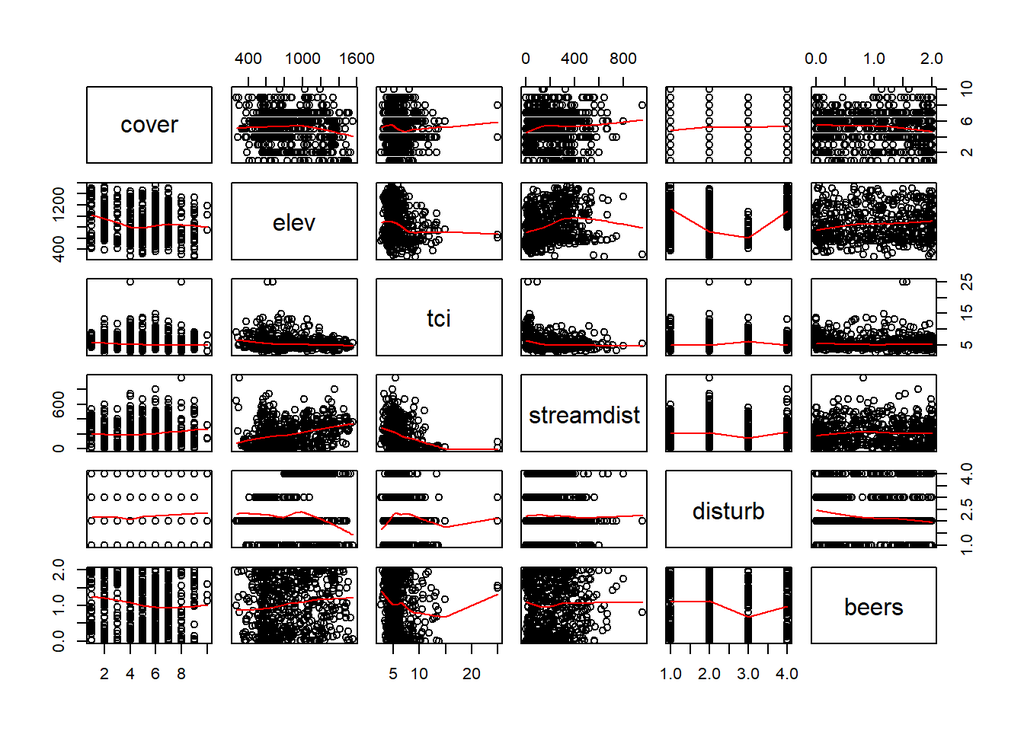

```r
pairs(acer_expvar, panel = panel.smooth)
```

According to this data, there are a few outliers, but the model generally fits okay. The Normal Q-Q plot shows most of the points on the dashed line. However, there are striped patterns in the Residuals vs. Fitted plot and the Scale-Location plot due to the integer values of cover. Point 365 has more leverage than the other data, and other outliers include 407 and 306.

The summary shows some significant p-values, but the adjusted R-squared is very low at 0.03558. Disturb should be removed first to make a better model.

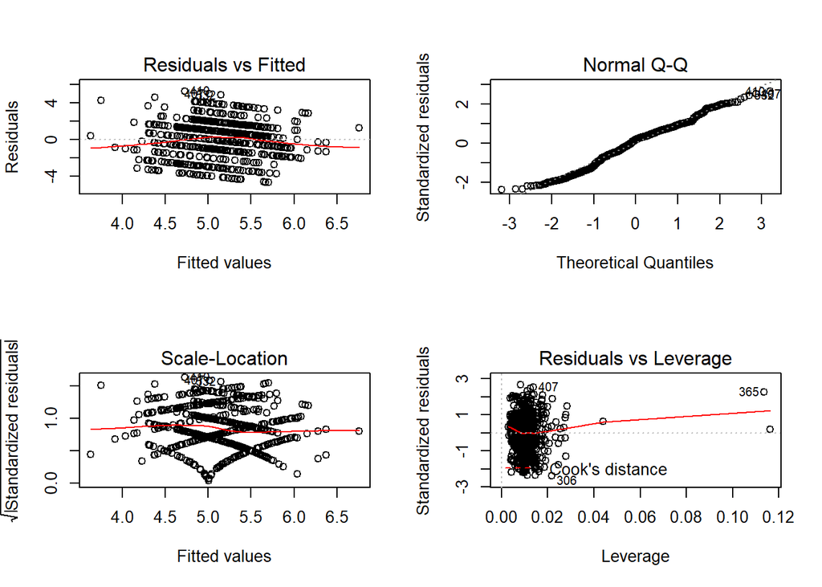

```r
acer_modmax = lm(cover ~ elev + tci + streamdist + disturb + beers, data =acer_sub)

par(mfrow=c(2,2))
plot(acer_modmax)
```

```r
summary(acer_modmax)
```

```
##
## Call:
## lm(formula = cover ~ elev + tci + streamdist + disturb + beers,
##     data = acer_sub)
##
## Residuals:
##     Min      1Q  Median      3Q     Max
## -4.7073 -1.2446  0.3409  1.3575  5.2732
##
## Coefficients:
##                 Estimate Std. Error t value Pr(>|t|)
## (Intercept)    6.3502303  0.4564973  13.911  < 2e-16 ***
## elev          -0.0010108  0.0003161  -3.197  0.00145 **
## tci           -0.0627613  0.0351922  -1.783  0.07495 .
## streamdist     0.0012895  0.0004756   2.712  0.00686 **
## disturbLT-SEL  0.0829610  0.2166747   0.383  0.70192
## disturbSETTLE -0.1044556  0.2804213  -0.372  0.70963
## disturbVIRGIN  0.3088364  0.2518161   1.226  0.22044
## beers         -0.3269597  0.1089662  -3.001  0.00279 **
## ---
## Signif. codes:  0 '***' 0.001 '**' 0.01 '*' 0.05 '.' 0.1 ' ' 1
##
## Residual standard error: 1.989 on 715 degrees of freedom
## Multiple R-squared:  0.04493,    Adjusted R-squared:  0.03558
## F-statistic: 4.805 on 7 and 715 DF,  p-value: 2.669e-05
```

```r
acer_modmax_wodist = update(acer_modmax, ~. -disturb, data=acer_sub)

summary(acer_modmax_wodist)
```

```
##
## Call:
## lm(formula = cover ~ elev + tci + streamdist + beers, data = acer_sub)
##
## Residuals:
##     Min      1Q  Median      3Q     Max
## -4.7869 -1.2983  0.3618  1.4014  5.2451
##
## Coefficients:
##               Estimate Std. Error t value Pr(>|t|)
## (Intercept)  6.3218898  0.3604346  17.540  < 2e-16 ***
## elev        -0.0008868  0.0002606  -3.403 0.000703 ***
## tci         -0.0668631  0.0350647  -1.907 0.056939 .
## streamdist   0.0013256  0.0004696   2.823 0.004893 **
## beers       -0.3204370  0.1068951  -2.998 0.002814 **
## ---
## Signif. codes:  0 '***' 0.001 '**' 0.01 '*' 0.05 '.' 0.1 ' ' 1
##
## Residual standard error: 1.988 on 718 degrees of freedom
## Multiple R-squared:  0.04174,    Adjusted R-squared:  0.0364
## F-statistic: 7.818 on 4 and 718 DF,  p-value: 3.603e-06
```

The adjusted R-square went up, so disturb is left out. Next, tci is removed.

```r
acer_wodist_wotci = update(acer_modmax_wodist, ~. -tci, data=acer_sub)

summary(acer_wodist_wotci)
```

```
##
## Call:
## lm(formula = cover ~ elev + streamdist + beers, data = acer_sub)
##
## Residuals:
##     Min      1Q  Median      3Q     Max
## -4.9339 -1.3307  0.2865  1.3691  5.2839
##
## Coefficients:
##               Estimate Std. Error t value Pr(>|t|)
## (Intercept)  5.8119219  0.2420805  24.008  < 2e-16 ***
## elev        -0.0008226  0.0002589  -3.178 0.001548 **
## streamdist   0.0015415  0.0004566   3.376 0.000774 ***
## beers       -0.3034710  0.1067192  -2.844 0.004587 **
## ---
## Signif. codes:  0 '***' 0.001 '**' 0.01 '*' 0.05 '.' 0.1 ' ' 1
##
## Residual standard error: 1.992 on 719 degrees of freedom
## Multiple R-squared:  0.03688,    Adjusted R-squared:  0.03287
## F-statistic: 9.178 on 3 and 719 DF,  p-value: 5.775e-06
```

The R-squared went down, so this variable is left in. The rest of the variables have significant p-values, so they should not be removed. For example, when the significant variable beers is removed, the R-squared goes down a lot. See below.

```r
acer_wodist_wobeers = update(acer_modmax_wodist, ~. -beers, data=acer_sub)

summary(acer_wodist_wobeers)
```

```
##
## Call:
## lm(formula = cover ~ elev + tci + streamdist, data = acer_sub)
##
## Residuals:
##     Min      1Q  Median      3Q     Max
## -4.5796 -1.3284  0.3288  1.4482  5.2510
##
## Coefficients:
##               Estimate Std. Error t value Pr(>|t|)
## (Intercept)  6.0197393  0.3479708  17.300  < 2e-16 ***
## elev        -0.0009854  0.0002599  -3.791 0.000162 ***
## tci         -0.0581140  0.0351366  -1.654 0.098575 .
## streamdist   0.0013596  0.0004721   2.880 0.004094 **
## ---
## Signif. codes:  0 '***' 0.001 '**' 0.01 '*' 0.05 '.' 0.1 ' ' 1
##
## Residual standard error: 1.999 on 719 degrees of freedom
## Multiple R-squared:  0.02974,    Adjusted R-squared:  0.0257
## F-statistic: 7.347 on 3 and 719 DF,  p-value: 7.44e-05
```

The AIC function comes to the same conclusion. The lowest AIC is achieved when just disturb is removed from the model.

```r
library(MASS)
stepAIC(acer_modmax)
```

```
## Start:  AIC=1002.17
## cover ~ elev + tci + streamdist + disturb + beers
##
##              Df Sum of Sq    RSS     AIC
## - disturb     3     9.449 2837.7  998.58
## <none>                    2828.2 1002.17
## - tci         1    12.581 2840.8 1003.37
## - streamdist  1    29.085 2857.3 1007.56
## - beers       1    35.613 2863.8 1009.21
## - elev        1    40.439 2868.7 1010.43
##
## Step:  AIC=998.58
## cover ~ elev + tci + streamdist + beers
##
##              Df Sum of Sq    RSS     AIC
## <none>                    2837.7  998.58
## - tci         1    14.370 2852.0 1000.23
## - streamdist  1    31.491 2869.2 1004.56
## - beers       1    35.515 2873.2 1005.57
## - elev        1    45.778 2883.4 1008.15
```

```
##
## Call:
## lm(formula = cover ~ elev + tci + streamdist + beers, data = acer_sub)
##
## Coefficients:
## (Intercept)         elev          tci   streamdist        beers
##   6.3218898   -0.0008868   -0.0668631    0.0013256   -0.3204370
```

The interactions identified in the pairs plot are tested to see if they can improve model fit.

```r
acer_simpmod = acer_modmax_wodist

acer_expvar = acer_sub[1:nrow(acer_sub), 4:9]
head(acer_expvar)
```

```
##    cover   elev      tci streamdist disturb     beers
## 48     6  896.1 4.705636     197.00 CORPLOG 1.9906803
## 49     7  947.3 4.447437     125.30 CORPLOG 0.8167341
## 50     5 1027.0 6.149170     174.60 CORPLOG 0.5860782
## 51     7  450.2 4.133772     202.50  LT-SEL 0.8601108
## 52     5  477.0 5.587310     134.20  LT-SEL 0.1009244
## 53     4  461.8 4.415634      31.62  LT-SEL 1.4324567
```

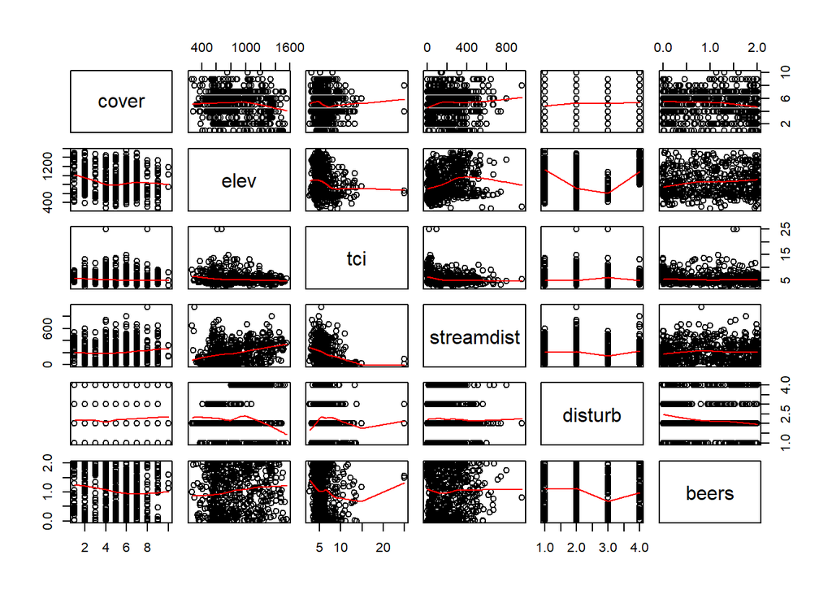

```r
pairs(acer_expvar, panel = panel.smooth)
```

```r
acer_simpmod_wint = update(acer_simpmod, ~. +elev*tci)
summary(acer_simpmod_wint)
```

```
##
## Call:
## lm(formula = cover ~ elev + tci + streamdist + beers + elev:tci,
##     data = acer_sub)
##
## Residuals:
##     Min      1Q  Median      3Q     Max
## -4.8549 -1.2995  0.3101  1.3998  5.5302
##
## Coefficients:
##               Estimate Std. Error t value Pr(>|t|)
## (Intercept)  4.7861498  0.7242112   6.609 7.56e-11 ***
## elev         0.0011634  0.0008788   1.324  0.18596
## tci          0.2091008  0.1182817   1.768  0.07752 .
## streamdist   0.0012528  0.0004689   2.672  0.00772 **
## beers       -0.3105952  0.1066037  -2.914  0.00368 **
## elev:tci    -0.0003753  0.0001537  -2.442  0.01484 *
## ---
## Signif. codes:  0 '***' 0.001 '**' 0.01 '*' 0.05 '.' 0.1 ' ' 1
##
## Residual standard error: 1.981 on 717 degrees of freedom
## Multiple R-squared:  0.04964,    Adjusted R-squared:  0.04301
## F-statistic:  7.49 on 5 and 717 DF,  p-value: 7.26e-07
```

Since the p-value went down, and the adjusted R-squared increased when the interaction between elev and tci was added, this interaction remains.

```r
acer_simpmod_wint2 = update(acer_simpmod_wint, ~. +elev*streamdist)
summary(acer_simpmod_wint2)
```

```
##
## Call:
## lm(formula = cover ~ elev + tci + streamdist + beers + elev:tci +
##     elev:streamdist, data = acer_sub)
##
## Residuals:
##     Min      1Q  Median      3Q     Max
## -4.9699 -1.3135  0.3179  1.3789  5.5621
##
## Coefficients:
##                   Estimate Std. Error t value Pr(>|t|)
## (Intercept)      4.268e+00  8.705e-01   4.903 1.17e-06 ***
## elev             1.811e-03  1.066e-03   1.699  0.08982 .
## tci              2.450e-01  1.229e-01   1.993  0.04664 *
## streamdist       2.544e-03  1.292e-03   1.969  0.04933 *
## beers           -3.014e-01  1.069e-01  -2.819  0.00496 **
## elev:tci        -4.216e-04  1.596e-04  -2.642  0.00843 **
## elev:streamdist -1.558e-06  1.453e-06  -1.072  0.28387
## ---
## Signif. codes:  0 '***' 0.001 '**' 0.01 '*' 0.05 '.' 0.1 ' ' 1
##
## Residual standard error: 1.981 on 716 degrees of freedom
## Multiple R-squared:  0.05117,    Adjusted R-squared:  0.04321
## F-statistic: 6.435 on 6 and 716 DF,  p-value: 1.28e-06
```

The p-value increased and this interaction is not significant, so it is removed.

```r
acer_simpmod_wint3 = update(acer_simpmod_wint, ~. +tci*streamdist)
summary(acer_simpmod_wint3)
```

```
##
## Call:
## lm(formula = cover ~ elev + tci + streamdist + beers + elev:tci +
##     tci:streamdist, data = acer_sub)
##
## Residuals:
##     Min      1Q  Median      3Q     Max
## -4.8292 -1.3029  0.3075  1.3978  5.5423
##
## Coefficients:
##                  Estimate Std. Error t value Pr(>|t|)
## (Intercept)     4.785e+00  7.249e-01   6.600 7.98e-11 ***
## elev            1.144e-03  9.011e-04   1.269  0.20469
## tci             2.095e-01  1.184e-01   1.769  0.07736 .
## streamdist      1.386e-03  1.430e-03   0.969  0.33273
## beers          -3.111e-01  1.068e-01  -2.913  0.00369 **
## elev:tci       -3.721e-04  1.571e-04  -2.369  0.01811 *
## tci:streamdist -2.373e-05  2.407e-04  -0.099  0.92149
## ---
## Signif. codes:  0 '***' 0.001 '**' 0.01 '*' 0.05 '.' 0.1 ' ' 1
##
## Residual standard error: 1.983 on 716 degrees of freedom
## Multiple R-squared:  0.04965,    Adjusted R-squared:  0.04169
## F-statistic: 6.235 on 6 and 716 DF,  p-value: 2.138e-06
```

The R-squared decreased, the p-value went up, and the interaction is not significant, so it was removed. The minimal adequate model includes all explanatory variables except disturb and the interaction between elev and tci.

```r
acer_simpmod = acer_simpmod_wint
```

```r
library(MASS)
Anova(acer_simpmod, type =3)
```

```
## Anova Table (Type III tests)
##
## Response: cover
##              Sum Sq  Df F value    Pr(>F)
## (Intercept)  171.43   1 43.6759 7.562e-11 ***
## elev           6.88   1  1.7527  0.185958
## tci           12.27   1  3.1252  0.077516 .
## streamdist    28.01   1  7.1373  0.007721 **
## beers         33.32   1  8.4888  0.003685 **
## elev:tci      23.41   1  5.9639  0.014842 *
## Residuals   2814.25 717
## ---
## Signif. codes:  0 '***' 0.001 '**' 0.01 '*' 0.05 '.' 0.1 ' ' 1
```

Again, the p-values between the summary and Anova functions are the same.

Because 407 and 410 appear as outliers in 3/4 of the plots and 365 exerts a lot more leverage than other datapoints, these are removed.

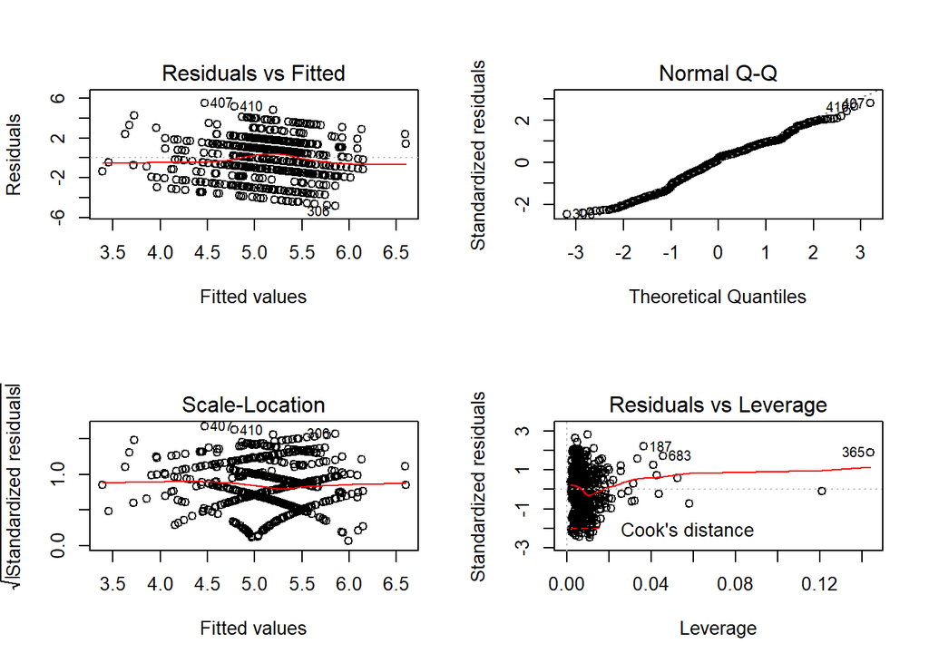

```r
par(mfrow = c(2,2))
plot(acer_simpmod)
```

```r
acer_sub_woout = acer_sub[-c(407, 410, 365),]
dim(acer_sub_woout)
```

```
## [1] 720   9
```

```r
dim(acer_sub)
```

```
## [1] 723   9
```

```r
acer_simpmod_woout = lm(cover~ elev + tci + streamdist + beers + elev*tci, data = acer_sub_woout)


summary(acer_simpmod_woout)
```

```
##
## Call:
## lm(formula = cover ~ elev + tci + streamdist + beers + elev *
##     tci, data = acer_sub_woout)
##
## Residuals:
##     Min      1Q  Median      3Q     Max
## -4.8432 -1.3025  0.3204  1.4102  5.5334
##
## Coefficients:
##               Estimate Std. Error t value Pr(>|t|)
## (Intercept)  4.8141766  0.7242785   6.647 5.95e-11 ***
## elev         0.0011179  0.0008793   1.271  0.20401
## tci          0.2053194  0.1182816   1.736  0.08302 .
## streamdist   0.0012221  0.0004691   2.605  0.00938 **
## beers       -0.3101498  0.1065949  -2.910  0.00373 **
## elev:tci    -0.0003686  0.0001538  -2.397  0.01677 *
## ---
## Signif. codes:  0 '***' 0.001 '**' 0.01 '*' 0.05 '.' 0.1 ' ' 1
##
## Residual standard error: 1.98 on 714 degrees of freedom
## Multiple R-squared:  0.04917,    Adjusted R-squared:  0.04251
## F-statistic: 7.384 on 5 and 714 DF,  p-value: 9.181e-07
```

## Question 1 Answers

```r
summary(abies_simpmod)
```

```
##
## Call:
## lm(formula = abies_sub$cover ~ abies_sub$elev + abies_sub$tci +
##     abies_sub$disturb)
##
## Residuals:
##     Min      1Q  Median      3Q     Max
## -3.8466 -0.6996  0.2255  0.8636  3.6846
##
## Coefficients:
##                          Estimate Std. Error t value Pr(>|t|)
## (Intercept)             -19.33664    3.90928  -4.946 1.57e-05 ***
## abies_sub$elev            0.01128    0.00200   5.641 1.77e-06 ***
## abies_sub$tci             0.28248    0.17025   1.659   0.1053
## abies_sub$disturbLT-SEL   2.54484    1.96059   1.298   0.2021
## abies_sub$disturbSETTLE   1.66160    2.26912   0.732   0.4685
## abies_sub$disturbVIRGIN   3.25929    1.63542   1.993   0.0535 .
## ---
## Signif. codes:  0 '***' 0.001 '**' 0.01 '*' 0.05 '.' 0.1 ' ' 1
##
## Residual standard error: 1.573 on 38 degrees of freedom
## Multiple R-squared:  0.5748, Adjusted R-squared:  0.5188
## F-statistic: 10.27 on 5 and 38 DF,  p-value: 2.774e-06
```

```r
summary(acer_simpmod)
```

```
##
## Call:
## lm(formula = cover ~ elev + tci + streamdist + beers + elev:tci,
##     data = acer_sub)
##
## Residuals:
##     Min      1Q  Median      3Q     Max
## -4.8549 -1.2995  0.3101  1.3998  5.5302
##
## Coefficients:
##               Estimate Std. Error t value Pr(>|t|)
## (Intercept)  4.7861498  0.7242112   6.609 7.56e-11 ***
## elev         0.0011634  0.0008788   1.324  0.18596
## tci          0.2091008  0.1182817   1.768  0.07752 .
## streamdist   0.0012528  0.0004689   2.672  0.00772 **
## beers       -0.3105952  0.1066037  -2.914  0.00368 **
## elev:tci    -0.0003753  0.0001537  -2.442  0.01484 *
## ---
## Signif. codes:  0 '***' 0.001 '**' 0.01 '*' 0.05 '.' 0.1 ' ' 1
##
## Residual standard error: 1.981 on 717 degrees of freedom
## Multiple R-squared:  0.04964,    Adjusted R-squared:  0.04301
## F-statistic:  7.49 on 5 and 717 DF,  p-value: 7.26e-07
```

Since the adjusted R-squared value was 0.5188 even when outliers were included and up to 0.7 when they were removed, the *Abies* model seems to explain cover relatively well. The *Acer* model does not explain cover well. While more of the explanatory variables are significant to the model, as shown by the p-values, the model only explains 4% of the variance in the data. The AIC value is also much lower for the *Abies* model (44.68) than the *Acer* model (998.58). This is another value that indicates the *Abies* model is a better fit for the data. This is not surprising because *Abies fraseri* is a habitat specialist, and *Acer rubrum* is a generalist. It is easier to predict where *Abies fraseri* will choose to live because it is pickier.

For the *Abies* model, elevation and whether the area is virgin forest are the most important explanatory variables. For the *Acer* model, distance from a stream and the transformed slope aspect are most important.

The main OLS assumptions are listed below. The plots for each model are below this discussion.

- The residuals are normally distributed.
  - The Q-Q plots for both *Abies* and *Acer* show that most of the points are on the dashed line. This means that the residuals are mostly normally distributed while there are some outliers.
- There is a linear response to the driver.
  - Since one of the exaplanatory variables is categorical (disturb) and the response variable (cover) is only integers (and therefore not fully continuous), there cannot be a linear response.
- Samples are independent.
  - I am not sure that we can address this issue the way the data was explored here. Some of the datapoints do have more leverage than others though.
- Equal variance (no heteroscedasticity).
  - The Residuals vs. Fitted and Scale Location plots for the *Abies* model have many of the points close together on the right rather than evenly distributed around the plot. This indicates that the data is slightly skewed, so there is not entirely equal variance. The Acer model has even more distinct patterns with lines of points in these plots. This has occurred because the response variable is in integers.

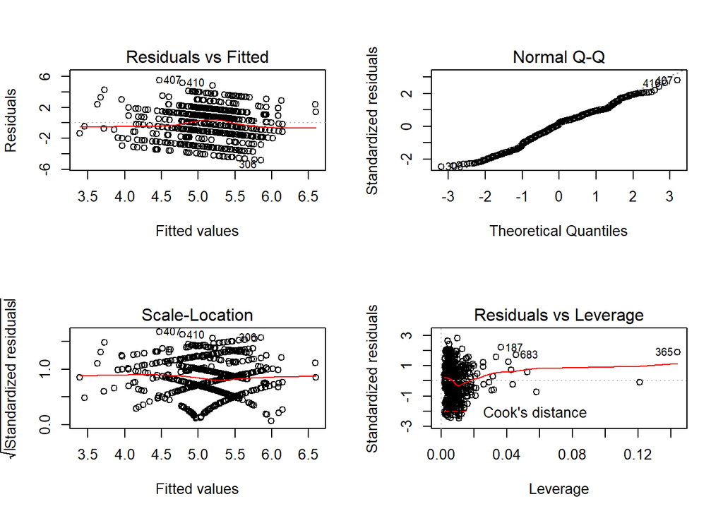

```r
par(mfrow = c(2,2))
plot(abies_simpmod)
par(mfrow = c(2,2))
plot(acer_simpmod)
```

[output not shown]

## Question 2

The OLS models are compared to models that assume residuals to be on a Poisson distribution as opposed to the Gaussian distribution. This should be a better fit since cover was measured in integers.

```r
#abies_ols is the same as abies_simpmod.  It is written using the glm function instead of lm, so the anova function can compare them.  Same is true of acer_ols.
abies_ols = glm(cover~ elev + tci + disturb, data = abies_sub, family = 'gaussian')
abies_glm = glm(cover~ elev + tci + disturb, data = abies_sub, family = 'poisson')

acer_ols = glm(cover~ elev + tci + streamdist + beers + elev*tci, data = acer_sub, family = 'gaussian')
acer_glm = glm(cover~ elev + tci + streamdist + beers + elev*tci, data = acer_sub, family = 'poisson')

pseudo_r2 = function(glm_mod) {
     1 -  glm_mod$deviance / glm_mod$null.deviance
}

pseudo_r2(abies_glm)
```

```
## [1] 0.601741
```

```r
pseudo_r2(acer_glm)
```

```
## [1] 0.04495864
```

These pseudo R-squared values are slightly higher than the adjusted R-squared for the previous models. The models with the poisson error are better fitted to the models.

The deviance of the two models is directly compared.

```r
anova(abies_glm, abies_ols)
```

```
## Analysis of Deviance Table
##
## Model 1: cover ~ elev + tci + disturb
## Model 2: cover ~ elev + tci + disturb
##   Resid. Df Resid. Dev Df Deviance
## 1        38     16.438
## 2        38     93.969  0  -77.531
```

There are 77 more units of cover that are deviant for the ols model than for the glm model. Therefore, the glm model fits much better. For acer, (below) the same is true except there are 2194 deviants.

```r
anova(acer_glm, acer_ols)
```

```
## Analysis of Deviance Table
##
## Model 1: cover ~ elev + tci + streamdist + beers + elev * tci
## Model 2: cover ~ elev + tci + streamdist + beers + elev * tci
##   Resid. Df Resid. Dev Df Deviance
## 1       717     620.15
## 2       717    2814.25  0  -2194.1
```

```r
summary(abies_glm)
```

```
##
## Call:
## glm(formula = cover ~ elev + tci + disturb, family = "poisson",
##     data = abies_sub)
##
## Deviance Residuals:
##     Min       1Q   Median       3Q      Max
## -1.6294  -0.3853   0.1468   0.3199   1.6710
##
## Coefficients:
##                 Estimate Std. Error z value Pr(>|z|)
## (Intercept)   -3.8775582  1.4874230  -2.607 0.009137 **
## elev           0.0021370  0.0006084   3.512 0.000444 ***
## tci            0.0579093  0.0470557   1.231 0.218453
## disturbLT-SEL  1.2882172  1.0666433   1.208 0.227151
## disturbSETTLE  1.0457481  1.1610404   0.901 0.367748
## disturbVIRGIN  1.4218988  1.0103315   1.407 0.159321
## ---
## Signif. codes:  0 '***' 0.001 '**' 0.01 '*' 0.05 '.' 0.1 ' ' 1
##
## (Dispersion parameter for poisson family taken to be 1)
##
##     Null deviance: 41.274  on 43  degrees of freedom
## Residual deviance: 16.438  on 38  degrees of freedom
## AIC: 185.61
##
## Number of Fisher Scoring iterations: 4
```

```r
summary(abies_ols)
```

```
##
## Call:
## glm(formula = cover ~ elev + tci + disturb, family = "gaussian",
##     data = abies_sub)
##
## Deviance Residuals:
##     Min       1Q   Median       3Q      Max
## -3.8466  -0.6996   0.2255   0.8636   3.6846
##
## Coefficients:
##                Estimate Std. Error t value Pr(>|t|)
## (Intercept)   -19.33664    3.90928  -4.946 1.57e-05 ***
## elev            0.01128    0.00200   5.641 1.77e-06 ***
## tci             0.28248    0.17025   1.659   0.1053
## disturbLT-SEL   2.54484    1.96059   1.298   0.2021
## disturbSETTLE   1.66160    2.26912   0.732   0.4685
## disturbVIRGIN   3.25929    1.63542   1.993   0.0535 .
## ---
## Signif. codes:  0 '***' 0.001 '**' 0.01 '*' 0.05 '.' 0.1 ' ' 1
##
## (Dispersion parameter for gaussian family taken to be 2.472865)
##
##     Null deviance: 220.977  on 43  degrees of freedom
## Residual deviance:  93.969  on 38  degrees of freedom
## AIC: 172.25
##
## Number of Fisher Scoring iterations: 2
```

```r
summary(acer_glm)
```

```
##
## Call:
## glm(formula = cover ~ elev + tci + streamdist + beers + elev *
##     tci, family = "poisson", data = acer_sub)
##
## Deviance Residuals:
##     Min       1Q   Median       3Q      Max
## -2.4920  -0.6036   0.1229   0.5911   2.2594
##
## Coefficients:
##               Estimate Std. Error z value Pr(>|z|)
## (Intercept)  1.548e+00  1.626e-01   9.516   <2e-16 ***
## elev         2.623e-04  1.996e-04   1.314   0.1889
## tci          4.454e-02  2.681e-02   1.662   0.0966 .
## streamdist   2.383e-04  1.023e-04   2.329   0.0199 *
## beers       -6.064e-02  2.378e-02  -2.551   0.0108 *
## elev:tci    -8.027e-05  3.542e-05  -2.266   0.0235 *
## ---
## Signif. codes:  0 '***' 0.001 '**' 0.01 '*' 0.05 '.' 0.1 ' ' 1
##
## (Dispersion parameter for poisson family taken to be 1)
##
##     Null deviance: 649.34  on 722  degrees of freedom
## Residual deviance: 620.15  on 717  degrees of freedom
## AIC: 3094.5
##
## Number of Fisher Scoring iterations: 4
```

```r
summary(acer_ols)
```

```
##
## Call:
## glm(formula = cover ~ elev + tci + streamdist + beers + elev *
##     tci, family = "gaussian", data = acer_sub)
##
## Deviance Residuals:
##     Min       1Q   Median       3Q      Max
## -4.8549  -1.2995   0.3101   1.3998   5.5302
##
## Coefficients:
##               Estimate Std. Error t value Pr(>|t|)
## (Intercept)  4.7861498  0.7242112   6.609 7.56e-11 ***
## elev         0.0011634  0.0008788   1.324  0.18596
## tci          0.2091008  0.1182817   1.768  0.07752 .
## streamdist   0.0012528  0.0004689   2.672  0.00772 **
## beers       -0.3105952  0.1066037  -2.914  0.00368 **
## elev:tci    -0.0003753  0.0001537  -2.442  0.01484 *
## ---
## Signif. codes:  0 '***' 0.001 '**' 0.01 '*' 0.05 '.' 0.1 ' ' 1
##
## (Dispersion parameter for gaussian family taken to be 3.925036)
##
##     Null deviance: 2961.3  on 722  degrees of freedom
## Residual deviance: 2814.3  on 717  degrees of freedom
## AIC: 3048.4
##
## Number of Fisher Scoring iterations: 2
```

## Question 3

To summarize all of the work done above, since Abies fraseri is a habitat specialist, a model can be built that describes the amount of area this tree will cover based on the elevation, water potential (topographic convergence index), and the disturbance history (particularly whether the site is high in virgin attributes or not). This model can explain up to 60% of the variation in cover based on these attributes of the given area when error in the model is integer-based. We can predict whether *Abies fraseri* would be abundant somewhere if we know the elevation and a few other parameters. The model for *Acer rubrum* can only explain 4% of its abundance in different areas because it does not really decide where to live based on the parameters the study measured. It can live at all sorts of elevations, soil water potentials, distances from streams, and transformed slope aspects. This model is much less predictive since *Acer rubrum* is a habitat generalist. We can conclude that univariate modeling works best when the ecological factor is significant to whether the tree can survive. We can also conclude that of all of the potential factors, elevation does the best job in explaining the observed abundance of these species.

## Question 4

The stepAIC function was used above in the exploratory analysis to compare this method to the chosen method conducted by hand. The computer and I reached very similar conclusions for the simplified models of both species.